[figure not shown]

# A co-created research agenda for the DSI community sustainability

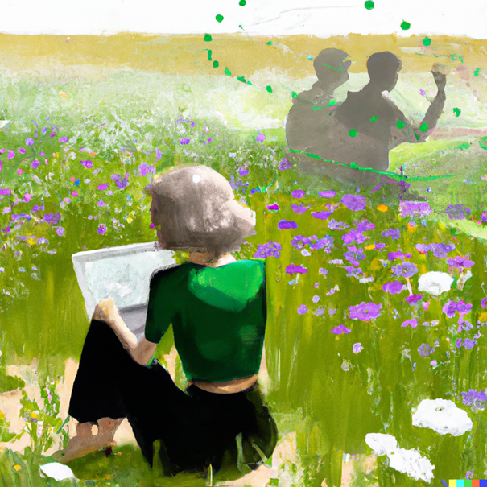

This is a living document. It contains the co-created research agenda of the [DSI community sustainability](https://www.dsi.uzh.ch/en/research/communities/sustainability.html).

The DSI community sustainability is a community of researchers brought together by the Digital Society Initiative ([DSI](https://www.dsi.uzh.ch)) at the University of Zürich who are interested in issues of *sustainable digitalization*.

This co-created research agenda is the product of a discussion process within the community, previous research sustainable digitalization and exchange with practitioners, especially during a roundtable discussion on the 12th May 2023.

## Three key themes for our research

### Provide clarity 🔦

We provide clarity among different concepts, definitions and approaches to sustainable digitalization.

### Measure impacts 🍃

We develop, test and share methodologies to measure sustainability impacts of digitalization.

### Gather solutions 🎯

We gather solutions to sustainable digitalization challenges coming from within and outside research, evaluate and organize them.

**What got left out (for the moment)**

Our key themes do not cover all relevant and possible research areas when it comes to sustainable digitalization research. We chose to focus on them based on priorities communicated to us from practicioners as well, the distribution of skills within our community and prioritizing issues with resource use implications. Crucial issues that have been left out for the moment include justice implications of surveillance technologies, ethical implications of [SALAMI](https://blog.quintarelli.it/2019/11/lets-forget-the-term-ai-lets-call-them-systematic-approaches-to-learning-algorithms-and-machine-inferences-salami/) (sometimes called AI) applications, the societal consequences of social media use in terms of collective capacity for sustainability transformations.

## Our approach

There is a high demand for research on sustainable digitalization, which prioritizes an active dialogue with society above traditional forms of making our knowledge available. For us this means that we want to:

- aim to include actors from all societal sectors throughout all stages of the research process, crucially including choices on what we research itself
- promote sustainable digitalization literacy among students

## Concrete next steps

- Create sub-groups according to the three themes (provide clarity, measure impacts, gather solutions)
- Define concrete research ideas and research projects for each sub-group
- Share the research ideas and research project proposals with practitioners and societal actors, inquiring feedback and seeking possible collaborations
- Start collaborating on research projects and submit at least one funding proposal in 2024

# Co-creation process

### 2022

In 2022, we first combined existing research on sustainable digitalization with within-community discussions during a pilot year for our community, which led to the successful application for recognition as an official DSI community.

A pointer and summaries on various aspects of the sustainable digitalization literature can be found in the resources prepared for a short PhD-level course [here](https://marioangst.github.io/susdigi_course/)

For a very recent overview on sustainable digitalization research with lots of good references for further reading, see [this 2023 special issue in GAIA.](https://www.ingentaconnect.com/content/oekom/gaia/2023/00000032/a00101s1)

### 2023

In 2023, we started a co-creation process to engage with a broader set of actors in the sustainable digitalization domain to arrive in a first interation at this research agenda.

- 🤝 Sustainable Digitalization Roundtable (12th of May 2023)

  On the 12th of May 2023, we organized a first roundtable “sustainable digitalization” with 15 practicioners from all societal sectors. During the roundtable, we focused on eliciting a) real-world challenges of and b) potential for solutions to sustainable digitalization in moderated small-group discussions. This research agenda is heavily influenced by the results of this roundtable and we want to continue shaping it in the future through similar processes.

# Findings

This section gives an extended summary over our findings, which led to our three key themes.

## General sustainable digitalization challenges

In general, integrating sustainability objectives into digitalization is seen as taking too much time. One central issue that was identified is the **lack of a definition or conceptualization of sustainability, digitalization**, and the combination of those two concepts respectively. As sustainability is increasingly seen as a marketing claim by the public, sustainable digitalization or digital sustainability is also increasingly perceived as a **buzzword** that leads to increased interest, without sufficient understanding of the underlying concepts.

Even though **theoretical knowledge** exists on sustainable digitalization (e.g., in academia and specialized consultancies), **access to this information is sometimes limited**, not widely known, or difficult to put in practice.

On a more structural level, **financial resources are often missing** for integrating sustainability objectives into digitalization processes on the individual, corporate, and societal levels. Funding in the sustainable digitalization domain almost exclusively focuses on efficiency targets. What is more, there is a generally likely **over-optimistic, technology-centric view** on the opportunities digitalization offers for sustainability.

Further, the **resource use impacts of digitalization** on a micro-level are often hard to define or remain **unknown**. In fact, it was lamented that methodologies and measurements of CO2 emissions and digital processes are often not fully understood or the **necessary data is not available.**

## Specific challenges in societal sectors

### Civil society

Civil society actors identified technological, social, environmental and political issues.

For example, the introduction of **[SALAMI](https://blog.quintarelli.it/2019/11/lets-forget-the-term-ai-lets-call-them-systematic-approaches-to-learning-algorithms-and-machine-inferences-salami/) (sometimes called AI) and bots poses unknown (ethical) risks and challenges** for society. Lack of knowledge about these tools and data generation processes among citizens create new **issues of digital justice** within and across generations. Due to the increased influence of big tech companies and their dominance in citizens’ daily lives, individuals become subject to new forms of exploitative structures (**data colonialism**) that inhibit their digital sovereignty. **Tech-driven solutionism** leads to climate change being increasingly debated as a matter of technological solutions, while social aspects are mostly disregarded. In general, there seems to be **limited awareness among individuals** about the concept of sustainable digitalization.

The **necessary skills** (as required by current technological and social infrastructures) among the broader public for developing and using solutions **are limited**, or in most cases lacking. Likewise, access to data and information is often lacking, even for information created through the use of public money.

The increased consumption, use, and replacement of technological devices that presumably save energy, time and costs lead to **rebound effects**, where more resources are eventually used to respond to the growing demand for technology, thereby exploiting natural resources. On a micro-level, devices become outdated too fast and have to be substituted too often (e.g., mobile phones), thereby producing **tremendous amounts of waste**. Besides the production and availability of technological devices, the generation of data has taken on enormous speed and dimensions, consuming **extreme amounts of energy.**

Related to the ubiquity of technical devices, citizens are exposed to an **abundance of digital information** that poses new challenges regarding the development of new strategies to deal with information overload. In some cases, addiction to digital technologies or social isolation are becoming more common and can cause harm for citizens’ mental health.

### Private sector

For corporations and the private sector, the link between digitalization and sustainability and how to think both processes together present a widely unknown territory. While the pressure to become sustainable is widely acknowledged, many corporate actors are not aware or **unsure about how to integrate sustainability objectives into digitalization processes**, or in current tools that support organizational work flows.

One central issue is that corporations seem to try to **incorporate sustainable digitalization approach within old business models**, without exploring new, transformative ways of doing business. For example, the idea of implementing digital and sustainable work processes along the entire supply chain (production, usage, disposal), in line with a circular economy model, remains in many cases disregarded.

Reasons for the lagging integration of sustainability objectives into existing digitalization processes in the private sector and the lack of new, transformative approaches to doing business are **limited time and resources** (even coming down eg. lacking space for on-premise servers) for implementing new processes, other **priorities** by top management, the **complexity** of services, or the **lack of data transfer and exchange** across enterprises that are part of the supply chain but which are necessary to adapt and change the processes to become more sustainable.

The market seems to lack suitable management tools that incorporate sustainability objectives into digital processes. This can either be due to a **lack of knowledge** among corporate actors, or due to **structural limitations** that hinder the development of such tools. Overall, corporate actors seem to **miss practical examples or use cases** that show the impact and benefit of incorporating sustainability objectives into digital solutions. This also comes along with decisions that have to be taken regarding data providers and servers or work-support-tools that comply with the idea of simultanuously operating digitally and sustainably.

Similar to individual citizens, corporations have become dependent on big technological firms and platforms in their daily work practices (e.g., Microsoft, Google). Another challenge that has been identified on the corporate level is the difficulty of **navigating through the regulations** at the intersection of digitalization and sustainability. For example, on the micro-level, corporations have to deal with an abundance of certifications that are hard to distinguish or deem trustworthy.

### Policymakers and state sector

Although authorities have pledged to move sustainability and digitalization forward in a “twin transformation” at least on paper, the connection of both processes has not been thoroughly thought through or enacted on the policy level. Therefore, there is a **lack of regulation** in that area, a **void in responsibility attributions** (usually seen as an EU-centered topic), and a general **slowness** in integrating both dimensions going forward.

Some legislation even seems to inhibit the sustainable and digital transformation of society, partly due to a **strong lobby from the corporate sector** that inhibits real change. More specifically, the political and democratic processes are seen by some as unable to keep up with fast-moving developments in the technological sector, and **funding is not effectively and rapidly directed** to producing (non)-commercial solutions.

Furthermore, access to publicly financed data is often not made available across regional borders to allow an efficient exchange of information, thereby accelerating processes that go beyond the public sector (e.g., climate, environmental data).

On a much higher level, policymakers will need to engage in a debate with society about how the transformation towards a sustainable and digital society **impacts current democratic processes**, such as elections, tax payments, administration, and deliberate decision-making.

# Community members

As of 3.7.2023

| Name | Email | Research Focus |
| --- | --- | --- |
| Alexandra Diehl | Diehl@ifi.uzh.ch | Visual Analytics, Weather Forecasting/Climate, Environment |
| Anna Schorn | a.schorn@ikmz.uzh.ch | Sustainability Communication |
| Benjamin Börner | benjamin.boerner@uzh.ch | Disability Office |
| Christian Hauser (external, FHGR) | Christian.Hauser@fhgr.ch | NA |
| Eva Maria Hakanson | evamaria.hakanson@uzh.ch | Innovation |
| Hoda Allahbakhshi | hoda.allahbakhshi@dsi.uzh.ch | Spatial Accessibility |
| Ingrid Oliva | i.oliva@ikmz.uzh.ch | Sustainable Finance |
| Jan Bieser | jan.bieser@ifi.uzh.ch | NA |
| Jeannette Behringer | behringer@sustainability.uzh.ch | Sustainability and Democracy/Participation; Sufficiency; Transdisciplinarity; Co-Production of Knowledge |
| Jonas Zellweger | jonas.zellweger@uzh.ch | NA |
| Julian Croci | croci@ifi.uzh.ch | Visualization, Accessibility |
| Leonard Creutzburg | creutzburg@sustainability.uzh.ch | NA |
| Lukas Hess | l.hess@ikmz.uzh.ch | NA |
| Lukas Tribelhorn | l.tribelhorn@ikmz.uzh.ch | Health Behaviour, Social-Media Use, Adolescents |
| Manuel Merki | manuel.merki@uzh.ch | Innovation Hub |
| Mario Angst | mario.angst@dsi.uzh.ch | Sustainability, Governance, Digitalization |
| Markos Mpadanes | m.mpadanes@ikmz.uzh.ch | Strategic CEO and Executive Communication & Corporate Social Advocacy |
| Markus Leippold | markus.leippold@bf.uzh.ch | Sustainable Finance, Natural Language Processing, Climate Economics, AI |
| Maximilian Fischer (external) | maximilian.fischer@m365.uni-konstanz.de | NA |
| Mike Schäfer | m.schaefer@ikmz.uzh.ch | Science Communication |
| Myriam Pham-Truffert | myriam.pham-truffert@geo.uzh.ch | 2030 Agenda |
| Nadine Strauß | n.strauss@ikmz.uzh.ch | Sustainability, Corporate Communication |
| Peter Ranacher | peter.ranacher@geo.uzh.ch | GIS |
| Philip Berntsen | Philip.berntsen@bf.uzh.ch | Sustainable finance, decentralized finance, tokenomics |
| Raphaela Kotsch | Raphaela.kotsch@uzh.ch | Climate Policy, Machine Learning |
| Sabrina Stöckli | sabrina.stoeckli@business.uzh.ch | Behavior change, sustainable behaviour |
| Sybilla Merian | sybilla.merian@business.uzh.ch | Interventions for sustainable food consumption |
| Tessa Consoli | tessa.consoli@ife.uzh.ch | Technology integration in schools, technology enhanced learning, digital inequality, digital citizenship education |
| Veruska Muccione | veruska.muccione@geo.uzh.ch | Climate risks, climate change adaptation and climate policy |
| Vesile Cinceoglu | vesile.cinceoglu@uzh.ch | Financial Communication |